# EasyVisa_SaiAdvaithVootukur_Full_Code

### Model Building with Oversampled data

```
Shape of oversampled X_train: (24846, 21)
Shape of oversampled y_train: (24846,)

Class distribution in oversampled y_train:
case_status
1    12423
0    12423
Name: count, dtype: int64

Decision Tree Classifier Model Performance on Original Training Set (after training on oversampled data):
```

|  | Accuracy | Recall | Precision | F1 |
| --- | --- | --- | --- | --- |
| 0 | 1.0 | 1.0 | 1.0 | 1.0 |

```
Decision Tree Classifier Model Performance on Original Testing Set (after training on oversampled data):
```

|  | Accuracy | Recall | Precision | F1 |
| --- | --- | --- | --- | --- |
| 0 | 0.651744 | 0.720566 | 0.748587 | 0.734309 |

```
Confusion Matrix for Decision Tree Classifier Model on Original Testing Set (after training on oversampled data):
```

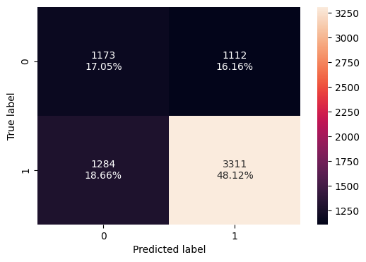

```python
# Apply SMOTE to the training data
sm = SMOTE(random_state=45)
X_train_oversampled, y_train_oversampled = sm.fit_resample(X_train, y_train)

print("Shape of oversampled X_train:", X_train_oversampled.shape)
print("Shape of oversampled y_train:", y_train_oversampled.shape)

# Check the class distribution in the oversampled target variable
print("\nClass distribution in oversampled y_train:")
print(y_train_oversampled.value_counts())

# Initialize and train a Decision Tree Classifier model on the oversampled data
dt_oversampled_model = DecisionTreeClassifier(random_state=45)
dt_oversampled_model.fit(X_train_oversampled, y_train_oversampled)

# Evaluate the model on the original training set (for comparison)
print("\nDecision Tree Classifier Model Performance on Original Training Set (after training on oversampled data):")
display(model_performance_classification_sklearn(dt_oversampled_model, X_train, y_train))


# Evaluate the model on the original testing set
print("\nDecision Tree Classifier Model Performance on Original Testing Set (after training on oversampled data):")
display(model_performance_classification_sklearn(dt_oversampled_model, X_test, y_test))

# Plot confusion matrix for the original testing set
print("\nConfusion Matrix for Decision Tree Classifier Model on Original Testing Set (after training on oversampled data):")
confusion_matrix_sklearn(dt_oversampled_model, X_test, y_test)
```

```
Logistic Regression Model Performance on Original Training Set (after training on oversampled data):
```

|  | Accuracy | Recall | Precision | F1 |
| --- | --- | --- | --- | --- |
| 0 | 0.723118 | 0.803188 | 0.786722 | 0.79487 |

```
Logistic Regression Model Performance on Original Testing Set (after training on oversampled data):
```

|  | Accuracy | Recall | Precision | F1 |
| --- | --- | --- | --- | --- |
| 0 | 0.725727 | 0.806094 | 0.788085 | 0.796988 |

```
Confusion Matrix for Logistic Regression Model on Original Testing Set (after training on oversampled data):
```

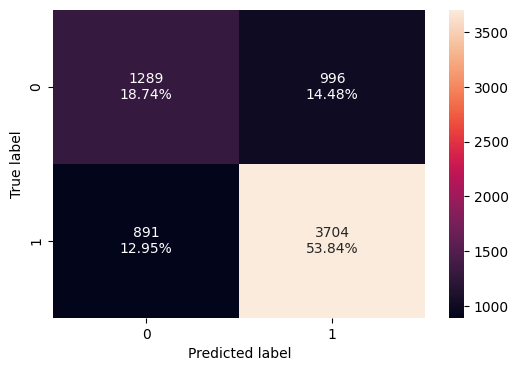

```python
# Initialize and train a Logistic Regression model on the oversampled data
lr_oversampled_model = LogisticRegression(random_state=45)
lr_oversampled_model.fit(X_train_oversampled, y_train_oversampled)

# Evaluate the model on the original training set (for comparison)
print("Logistic Regression Model Performance on Original Training Set (after training on oversampled data):")
display(model_performance_classification_sklearn(lr_oversampled_model, X_train, y_train))

# Evaluate the model on the original testing set
print("\nLogistic Regression Model Performance on Original Testing Set (after training on oversampled data):")
display(model_performance_classification_sklearn(lr_oversampled_model, X_test, y_test))

# Plot confusion matrix for the original testing set
print("\nConfusion Matrix for Logistic Regression Model on Original Testing Set (after training on oversampled data):")
confusion_matrix_sklearn(lr_oversampled_model, X_test, y_test)
```

### Model Building with Undersampled data

```
Shape of undersampled X_train: (12354, 21)
Shape of undersampled y_train: (12354,)

Class distribution in undersampled y_train:
case_status
0    6177
1    6177
Name: count, dtype: int64

Logistic Regression Model Performance on Original Training Set (after training on undersampled data):
```

|  | Accuracy | Recall | Precision | F1 |
| --- | --- | --- | --- | --- |
| 0 | 0.707204 | 0.718104 | 0.821077 | 0.766146 |

```
Logistic Regression Model Performance on Original Testing Set (after training on undersampled data):
```

|  | Accuracy | Recall | Precision | F1 |
| --- | --- | --- | --- | --- |
| 0 | 0.70625 | 0.721219 | 0.817464 | 0.766331 |

```
Confusion Matrix for Logistic Regression Model on Original Testing Set (after training on undersampled data):
```

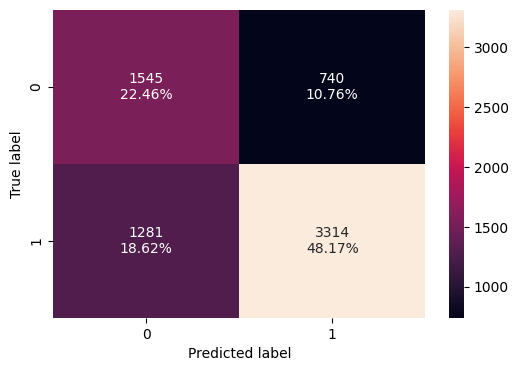

```python
# Apply Random Under-sampling to the training data
rus = RandomUnderSampler(random_state=45)
X_train_undersampled, y_train_undersampled = rus.fit_resample(X_train, y_train)

print("Shape of undersampled X_train:", X_train_undersampled.shape)
print("Shape of undersampled y_train:", y_train_undersampled.shape)

# Check the class distribution in the undersampled target variable
print("\nClass distribution in undersampled y_train:")
print(y_train_undersampled.value_counts())

# Initialize and train a Logistic Regression model on the undersampled data
lr_undersampled_model = LogisticRegression(random_state=45)
lr_undersampled_model.fit(X_train_undersampled, y_train_undersampled)

# Evaluate the Logistic Regression model on the original training set (for comparison)
print("\nLogistic Regression Model Performance on Original Training Set (after training on undersampled data):")
display(model_performance_classification_sklearn(lr_undersampled_model, X_train, y_train))

# Evaluate the Logistic Regression model on the original testing set
print("\nLogistic Regression Model Performance on Original Testing Set (after training on undersampled data):")
display(model_performance_classification_sklearn(lr_undersampled_model, X_test, y_test))

# Plot confusion matrix for the Logistic Regression model on the original testing set
print("\nConfusion Matrix for Logistic Regression Model on Original Testing Set (after training on undersampled data):")
confusion_matrix_sklearn(lr_undersampled_model, X_test, y_test)
```

```
Decision Tree Classifier Model Performance on Original Training Set (after training on undersampled data):
```

|  | Accuracy | Recall | Precision | F1 |
| --- | --- | --- | --- | --- |
| 0 | 0.867312 | 0.801336 | 1.0 | 0.889713 |

```
Decision Tree Classifier Model Performance on Original Testing Set (after training on undersampled data):
```

|  | Accuracy | Recall | Precision | F1 |
| --- | --- | --- | --- | --- |
| 0 | 0.624564 | 0.62568 | 0.769128 | 0.690028 |

```
Confusion Matrix for Decision Tree Classifier Model on Original Testing Set (after training on undersampled data):
```

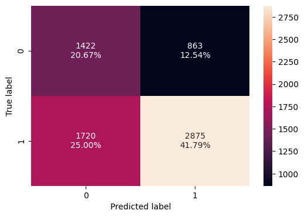

```python
# Initialize and train a Decision Tree Classifier model on the undersampled data
dt_undersampled_model = DecisionTreeClassifier(random_state=45)
dt_undersampled_model.fit(X_train_undersampled, y_train_undersampled)

# Evaluate the Decision Tree Classifier model on the original training set (for comparison)
print("\nDecision Tree Classifier Model Performance on Original Training Set (after training on undersampled data):")
display(model_performance_classification_sklearn(dt_undersampled_model, X_train, y_train))

# Evaluate the Decision Tree Classifier model on the original testing set
print("\nDecision Tree Classifier Model Performance on Original Testing Set (after training on undersampled data):")
display(model_performance_classification_sklearn(dt_undersampled_model, X_test, y_test))

# Plot confusion matrix for the Decision Tree Classifier model on the original testing set
print("\nConfusion Matrix for Decision Tree Classifier Model on Original Testing Set (after training on undersampled data):")
confusion_matrix_sklearn(dt_undersampled_model, X_test, y_test)
```

## Hyperparameter Tuning

**Best practices for hyperparameter tuning in AdaBoost:**

`n_estimators`:

- Start with a specific number (50 is used in general) and increase in steps: 50, 75, 85, 100
- Use fewer estimators (e.g., 50 to 100) if using complex base learners (like deeper decision trees)
- Use more estimators (e.g., 100 to 150) when learning rate is low (e.g., 0.1 or lower)
- Avoid very high values unless performance keeps improving on validation

`learning_rate`:

- Common values to try: 1.0, 0.5, 0.1, 0.01
- Use 1.0 for faster training, suitable for fewer estimators
- Use 0.1 or 0.01 when using more estimators to improve generalization
- Avoid very small values (< 0.01) unless you plan to use many estimators (e.g., >500) and have sufficient data

**Best practices for hyperparameter tuning in Random Forest:**

`n_estimators`:

- Start with a specific number (50 is used in general) and increase in steps: 50, 75, 100, 125
- Higher values generally improve performance but increase training time
- Use 100-150 for large datasets or when variance is high

`min_samples_leaf`:

- Try values like: 1, 2, 4, 5, 10
- Higher values reduce model complexity and help prevent overfitting
- Use 1–2 for low-bias models, higher (like 5 or 10) for more regularized models
- Works well in noisy datasets to smooth predictions

`max_features`:

- Try values: `"sqrt"` (default for classification), `"log2"`, `None`, or float values (e.g., `0.3`, `0.5`)
- `"sqrt"` balances between diversity and performance for classification tasks
- Lower values (e.g., `0.3`) increase tree diversity, reducing overfitting
- Higher values (closer to `1.0`) may capture more interactions but risk overfitting

`max_samples` (for bootstrap sampling):

- Try float values between `0.5` to `1.0` or fixed integers
- Use `0.6–0.9` to introduce randomness and reduce overfitting
- Smaller values increase diversity between trees, improving generalization

**Best practices for hyperparameter tuning in Gradient Boosting:**

`n_estimators`:

- Start with 100 (default) and increase: 100, 200, 300, 500
- Typically, higher values lead to better performance, but they also increase training time
- Use 200–500 for larger datasets or complex problems
- Monitor validation performance to avoid overfitting, as too many estimators can degrade generalization

`learning_rate`:

- Common values to try: 0.1, 0.05, 0.01, 0.005
- Use lower values (e.g., 0.01 or 0.005) if you are using many estimators (e.g., > 200)
- Higher learning rates (e.g., 0.1) can be used with fewer estimators for faster convergence
- Always balance the learning rate with `n_estimators` to prevent overfitting or underfitting

`subsample`:

- Common values: 0.7, 0.8, 0.9, 1.0
- Use a value between `0.7` and `0.9` for improved generalization by introducing randomness
- `1.0` uses the full dataset for each boosting round, potentially leading to overfitting
- Reducing `subsample` can help reduce overfitting, especially in smaller datasets

`max_features`:

- Common values: `"sqrt"`, `"log2"`, or float (e.g., `0.3`, `0.5`)
- `"sqrt"` (default) works well for classification tasks
- Lower values (e.g., `0.3`) help reduce overfitting by limiting the number of features considered at each split

**Best practices for hyperparameter tuning in XGBoost:**

`n_estimators`:

- Start with 50 and increase in steps: 50,75,100,125.
- Use more estimators (e.g., 150-250) when using lower learning rates
- Monitor validation performance
- High values improve learning but increase training time

`subsample`:

- Common values: 0.5, 0.7, 0.8, 1.0
- Use `0.7–0.9` to introduce randomness and reduce overfitting
- `1.0` uses the full dataset in each boosting round; may overfit on small datasets
- Values < 0.5 are rarely useful unless dataset is very large

`gamma`:

- Try values: 0 (default), 1, 3, 5, 8
- Controls minimum loss reduction needed for a split
- Higher values make the algorithm more conservative (i.e., fewer splits)
- Use values > 0 to regularize and reduce overfitting, especially on noisy data

`colsample_bytree`:

- Try values: 0.3, 0.5, 0.7, 1.0
- Fraction of features sampled per tree
- Lower values (e.g., 0.3 or 0.5) increase randomness and improve generalization
- Use `1.0` when you want all features considered for every tree

`colsample_bylevel`:

- Try values: 0.3, 0.5, 0.7, 1.0
- Fraction of features sampled at each tree level (i.e., per split depth)
- Lower values help in regularization and reducing overfitting
- Often used in combination with `colsample_bytree` for fine control over feature sampling

## Tuning the Decision Tree model built on the original data

```
Fitting 5 folds for each of 160 candidates, totalling 800 fits
Best parameters for Decision Tree: {'criterion': 'gini', 'max_depth': None, 'min_samples_leaf': 2, 'min_samples_split': 2}
Best cross-validation recall (minority class) score: 0.5267890413112692

Best Decision Tree Model Performance on Training Set:
```

|  | Accuracy | Recall | Precision | F1 |
| --- | --- | --- | --- | --- |
| 0 | 0.934624 | 0.916928 | 0.984104 | 0.949329 |

```
Best Decision Tree Model Performance on Testing Set:
```

|  | Accuracy | Recall | Precision | F1 |
| --- | --- | --- | --- | --- |
| 0 | 0.64593 | 0.702285 | 0.751339 | 0.725984 |

```
Confusion Matrix for Best Decision Tree Model on Testing Set:
```

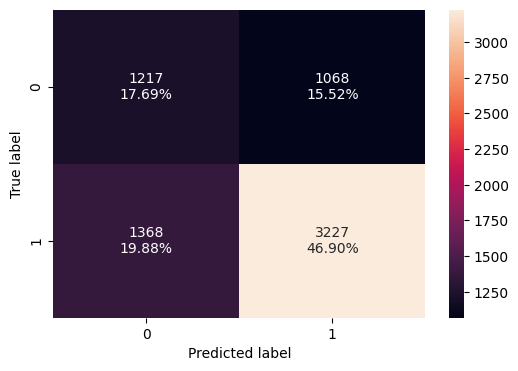

```python
# Define the parameter grid for Decision Tree
param_grid_dt = {
    'max_depth': [None, 5, 10, 15, 20],
    'min_samples_split': [2, 5, 10, 20],
    'min_samples_leaf': [1, 2, 5, 10],
    'criterion': ['gini', 'entropy']
}

# Initialize the Decision Tree Classifier
dt = DecisionTreeClassifier(random_state=45)

# Initialize GridSearchCV with recall as the scoring metric for the minority class (0 - Denied)
# We need to define a scorer for the minority class.
from sklearn.metrics import make_scorer, recall_score
recall_scorer = make_scorer(recall_score, pos_label=0)


grid_search_dt = GridSearchCV(estimator=dt, param_grid=param_grid_dt, cv=5, scoring=recall_scorer, n_jobs=-1, verbose=1)

# Fit the GridSearchCV to the training data
grid_search_dt.fit(X_train, y_train)

# Get the best parameters and best score
best_params_dt = grid_search_dt.best_params_
best_score_dt = grid_search_dt.best_score_

print("Best parameters for Decision Tree:", best_params_dt)
print("Best cross-validation recall (minority class) score:", best_score_dt)

# Get the best model
best_dt_model = grid_search_dt.best_estimator_

# Evaluate the best model on the training set
print("\nBest Decision Tree Model Performance on Training Set:")
display(model_performance_classification_sklearn(best_dt_model, X_train, y_train))

# Evaluate the best model on the testing set
print("\nBest Decision Tree Model Performance on Testing Set:")
display(model_performance_classification_sklearn(best_dt_model, X_test, y_test))

# Plot confusion matrix for the best model on the testing set
print("\nConfusion Matrix for Best Decision Tree Model on Testing Set:")
confusion_matrix_sklearn(best_dt_model, X_test, y_test)
```

## Tuning the Decision Tree model built on the oversampled data

```
Fitting 5 folds for each of 160 candidates, totalling 800 fits
Best parameters for Decision Tree on oversampled data: {'criterion': 'gini', 'max_depth': None, 'min_samples_leaf': 2, 'min_samples_split': 5}
Best cross-validation recall (minority class) score on oversampled data: 0.7383733641786305

Best Decision Tree Model Performance on Original Training Set (after tuning on oversampled data):
```

|  | Accuracy | Recall | Precision | F1 |
| --- | --- | --- | --- | --- |
| 0 | 0.92629 | 0.910569 | 0.977532 | 0.942863 |

```
Best Decision Tree Model Performance on Original Testing Set (after tuning on oversampled data):
```

|  | Accuracy | Recall | Precision | F1 |
| --- | --- | --- | --- | --- |
| 0 | 0.636192 | 0.673123 | 0.755496 | 0.711935 |

```
Confusion Matrix for Best Decision Tree Model on Original Testing Set (after tuning on oversampled data):
```

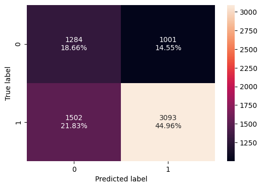

```python
# Define the parameter grid for Decision Tree
param_grid_dt = {
    'max_depth': [None, 5, 10, 15, 20],
    'min_samples_split': [2, 5, 10, 20],
    'min_samples_leaf': [1, 2, 5, 10],
    'criterion': ['gini', 'entropy']
}

# Initialize the Decision Tree Classifier
dt = DecisionTreeClassifier(random_state=45)

# Initialize GridSearchCV with recall as the scoring metric for the minority class (0 - Denied)
# We need to define a scorer for the minority class.
from sklearn.metrics import make_scorer, recall_score
recall_scorer = make_scorer(recall_score, pos_label=0)

# Use the oversampled training data for tuning
grid_search_dt_oversampled = GridSearchCV(estimator=dt, param_grid=param_grid_dt, cv=5, scoring=recall_scorer, n_jobs=-1, verbose=1)

# Fit the GridSearchCV to the oversampled training data
grid_search_dt_oversampled.fit(X_train_oversampled, y_train_oversampled)

# Get the best parameters and best score
best_params_dt_oversampled = grid_search_dt_oversampled.best_params_
best_score_dt_oversampled = grid_search_dt_oversampled.best_score_

print("Best parameters for Decision Tree on oversampled data:", best_params_dt_oversampled)
print("Best cross-validation recall (minority class) score on oversampled data:", best_score_dt_oversampled)

# Get the best model
best_dt_oversampled_model = grid_search_dt_oversampled.best_estimator_

# Evaluate the best model on the original training set (for comparison)
print("\nBest Decision Tree Model Performance on Original Training Set (after tuning on oversampled data):")
display(model_performance_classification_sklearn(best_dt_oversampled_model, X_train, y_train))

# Evaluate the best model on the original testing set
print("\nBest Decision Tree Model Performance on Original Testing Set (after tuning on oversampled data):")
display(model_performance_classification_sklearn(best_dt_oversampled_model, X_test, y_test))

# Plot confusion matrix for the best model on the original testing set
print("\nConfusion Matrix for Best Decision Tree Model on Original Testing Set (after tuning on oversampled data):")
confusion_matrix_sklearn(best_dt_oversampled_model, X_test, y_test)
```

## Tuning the Decision Tree model built on the undersampled data

```
Fitting 5 folds for each of 160 candidates, totalling 800 fits
Best parameters for Decision Tree on undersampled data: {'criterion': 'gini', 'max_depth': 15, 'min_samples_leaf': 2, 'min_samples_split': 20}
Best cross-validation recall (minority class) score on undersampled data: 0.679618725679022

Best Decision Tree Model Performance on Original Training Set (after tuning on undersampled data):
```

|  | Accuracy | Recall | Precision | F1 |
| --- | --- | --- | --- | --- |
| 0 | 0.738656 | 0.714401 | 0.871123 | 0.785016 |

```
Best Decision Tree Classifier Model Performance on Original Testing Set (after tuning on undersampled data):
```

|  | Accuracy | Recall | Precision | F1 |
| --- | --- | --- | --- | --- |
| 0 | 0.668023 | 0.662677 | 0.805769 | 0.727251 |

```
Confusion Matrix for Best Decision Tree Model on Original Testing Set (after tuning on undersampled data):
```

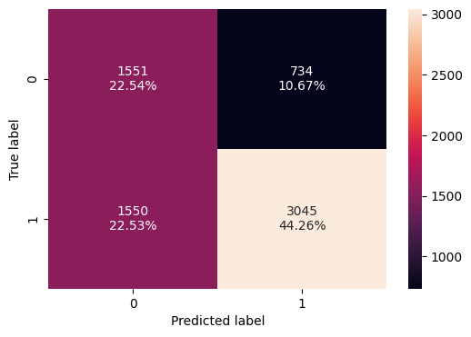

```python
# Define the parameter grid for Decision Tree
param_grid_dt = {
    'max_depth': [None, 5, 10, 15, 20],
    'min_samples_split': [2, 5, 10, 20],
    'min_samples_leaf': [1, 2, 5, 10],
    'criterion': ['gini', 'entropy']
}

# Initialize the Decision Tree Classifier
dt = DecisionTreeClassifier(random_state=45)

# Initialize GridSearchCV with recall as the scoring metric for the minority class (0 - Denied)
# We need to define a scorer for the minority class.
from sklearn.metrics import make_scorer, recall_score
recall_scorer = make_scorer(recall_score, pos_label=0)

# Use the undersampled training data for tuning
grid_search_dt_undersampled = GridSearchCV(estimator=dt, param_grid=param_grid_dt, cv=5, scoring=recall_scorer, n_jobs=-1, verbose=1)

# Fit the GridSearchCV to the undersampled training data
grid_search_dt_undersampled.fit(X_train_undersampled, y_train_undersampled)

# Get the best parameters and best score
best_params_dt_undersampled = grid_search_dt_undersampled.best_params_
best_score_dt_undersampled = grid_search_dt_undersampled.best_score_

print("Best parameters for Decision Tree on undersampled data:", best_params_dt_undersampled)
print("Best cross-validation recall (minority class) score on undersampled data:", best_score_dt_undersampled)

# Get the best model
best_dt_undersampled_model = grid_search_dt_undersampled.best_estimator_

# Evaluate the best model on the original training set (for comparison)
print("\nBest Decision Tree Model Performance on Original Training Set (after tuning on undersampled data):")
display(model_performance_classification_sklearn(best_dt_undersampled_model, X_train, y_train))

# Evaluate the best model on the original testing set
print("\nBest Decision Tree Classifier Model Performance on Original Testing Set (after tuning on undersampled data):")
display(model_performance_classification_sklearn(best_dt_undersampled_model, X_test, y_test))

# Plot confusion matrix for the best model on the original testing set
print("\nConfusion Matrix for Best Decision Tree Model on Original Testing Set (after tuning on undersampled data):")
confusion_matrix_sklearn(best_dt_undersampled_model, X_test, y_test)
```

## Model Performance Summary and Final Model Selection

```python
# Create a dictionary to store model performance metrics
model_performance = {}

# Function to add model performance to the dictionary
def add_model_performance(model_name, model, X, y):
    performance = model_performance_classification_sklearn(model, X, y)
    model_performance[model_name] = performance.iloc[0].to_dict()

# Add performance of models trained on original data
add_model_performance("Logistic Regression (Original Data)", Visa_OGmodel, X_test, y_test)
add_model_performance("Decision Tree (Original Data)", dt_model, X_test, y_test)
add_model_performance("Tuned Decision Tree (Original Data)", best_dt_model, X_test, y_test)


# Add performance of models trained on oversampled data
add_model_performance("Logistic Regression (Oversampled Data)", lr_oversampled_model, X_test, y_test)
add_model_performance("Decision Tree (Oversampled Data)", dt_oversampled_model, X_test, y_test)
add_model_performance("Tuned Decision Tree (Oversampled Data)", best_dt_oversampled_model, X_test, y_test)


# Add performance of models trained on undersampled data
add_model_performance("Logistic Regression (Undersampled Data)", lr_undersampled_model, X_test, y_test)
add_model_performance("Decision Tree (Undersampled Data)", dt_undersampled_model, X_test, y_test)
add_model_performance("Tuned Decision Tree (Undersampled Data)", best_dt_undersampled_model, X_test, y_test)


# Convert the dictionary to a pandas DataFrame for easy viewing
model_performance_df = pd.DataFrame.from_dict(model_performance, orient='index')

# Display the performance summary
print("Model Performance Summary:")
display(model_performance_df)
```

```
Model Performance Summary:
```

|  | Accuracy | Recall | Precision | F1 |
| --- | --- | --- | --- | --- |
| Logistic Regression (Original Data) | 0.742878 | 0.891404 | 0.763325 | 0.822407 |
| Decision Tree (Original Data) | 0.662500 | 0.747552 | 0.747226 | 0.747389 |
| Tuned Decision Tree (Original Data) | 0.645930 | 0.702285 | 0.751339 | 0.725984 |
| Logistic Regression (Oversampled Data) | 0.725727 | 0.806094 | 0.788085 | 0.796988 |
| Decision Tree (Oversampled Data) | 0.651744 | 0.720566 | 0.748587 | 0.734309 |
| Tuned Decision Tree (Oversampled Data) | 0.636192 | 0.673123 | 0.755496 | 0.711935 |
| Logistic Regression (Undersampled Data) | 0.706250 | 0.721219 | 0.817464 | 0.766331 |
| Decision Tree (Undersampled Data) | 0.624564 | 0.625680 | 0.769128 | 0.690028 |
| Tuned Decision Tree (Undersampled Data) | 0.668023 | 0.662677 | 0.805769 | 0.727251 |